# project 2

## Introduction

This dataset collects information from 100k medical appointments in Brazil and is focused on the question of whether or not patients show up for their appointment. A number of characteristics about the patient are included in each row.\ ● ‘ScheduledDay’ tells us on what day the patient set up their appointment.\ ● ‘Neighborhood’ indicates the location of the hospital.\ ● ‘Scholarship’ indicates whether or not the patient is enrolled in Brasilian welfare program Bolsa Família.\ ● Be careful about the encoding of the last column: it says ‘No’ if the patient showed up to their appointment, and ‘Yes’ if they did not show up.

### Questions to be answered

**Q1: Can age affect showing at the appointments\ Q2: Can condition affect why indivduals might not show up for their appointments?\ Q3: does gender affect why indivduals might not show up for their appointments\ Q4: Does The waiting days affect on showing to the appointment\ Q5: What are the top and least neighborhoods to no show up for their appointments\ Q6: Does not recieving sms affect not showing to the appointments**

```python
# Importing libraries
import pandas as pd
import numpy as np
import matplotlib.pyplot as plt
import seaborn as sns
import time
import datetime as dt
%matplotlib inline
```

## loading data set

```python
#load dataset
df=pd.read_csv('noshow.csv')
```

## Assesing Data

```python
df.head()
```

|  | PatientId | AppointmentID | Gender | ScheduledDay | AppointmentDay | Age | Neighbourhood | Scholarship | Hipertension | Diabetes | Alcoholism | Handcap | SMS_received | No-show |
| --- | --- | --- | --- | --- | --- | --- | --- | --- | --- | --- | --- | --- | --- | --- |
| 0 | 2.987250e+13 | 5642903 | F | 2016-04-29T18:38:08Z | 2016-04-29T00:00:00Z | 62 | JARDIM DA PENHA | 0 | 1 | 0 | 0 | 0 | 0 | No |
| 1 | 5.589978e+14 | 5642503 | M | 2016-04-29T16:08:27Z | 2016-04-29T00:00:00Z | 56 | JARDIM DA PENHA | 0 | 0 | 0 | 0 | 0 | 0 | No |
| 2 | 4.262962e+12 | 5642549 | F | 2016-04-29T16:19:04Z | 2016-04-29T00:00:00Z | 62 | MATA DA PRAIA | 0 | 0 | 0 | 0 | 0 | 0 | No |
| 3 | 8.679512e+11 | 5642828 | F | 2016-04-29T17:29:31Z | 2016-04-29T00:00:00Z | 8 | PONTAL DE CAMBURI | 0 | 0 | 0 | 0 | 0 | 0 | No |
| 4 | 8.841186e+12 | 5642494 | F | 2016-04-29T16:07:23Z | 2016-04-29T00:00:00Z | 56 | JARDIM DA PENHA | 0 | 1 | 1 | 0 | 0 | 0 | No |

```python
df.shape
```

```
(110527, 14)
```

```python
df.info()
```

```
<class 'pandas.core.frame.DataFrame'>
RangeIndex: 110527 entries, 0 to 110526
Data columns (total 14 columns):
 #   Column          Non-Null Count   Dtype
---  ------          --------------   -----
 0   PatientId       110527 non-null  float64
 1   AppointmentID   110527 non-null  int64
 2   Gender          110527 non-null  object
 3   ScheduledDay    110527 non-null  object
 4   AppointmentDay  110527 non-null  object
 5   Age             110527 non-null  int64
 6   Neighbourhood   110527 non-null  object
 7   Scholarship     110527 non-null  int64
 8   Hipertension    110527 non-null  int64
 9   Diabetes        110527 non-null  int64
 10  Alcoholism      110527 non-null  int64
 11  Handcap         110527 non-null  int64
 12  SMS_received    110527 non-null  int64
 13  No-show         110527 non-null  object
dtypes: float64(1), int64(8), object(5)
memory usage: 11.8+ MB
```

```python
df.describe()
```

|  | PatientId | AppointmentID | Age | Scholarship | Hipertension | Diabetes | Alcoholism | Handcap | SMS_received |
| --- | --- | --- | --- | --- | --- | --- | --- | --- | --- |
| count | 1.105270e+05 | 1.105270e+05 | 110527.000000 | 110527.000000 | 110527.000000 | 110527.000000 | 110527.000000 | 110527.000000 | 110527.000000 |
| mean | 1.474963e+14 | 5.675305e+06 | 37.088874 | 0.098266 | 0.197246 | 0.071865 | 0.030400 | 0.022248 | 0.321026 |
| std | 2.560949e+14 | 7.129575e+04 | 23.110205 | 0.297675 | 0.397921 | 0.258265 | 0.171686 | 0.161543 | 0.466873 |
| min | 3.921784e+04 | 5.030230e+06 | -1.000000 | 0.000000 | 0.000000 | 0.000000 | 0.000000 | 0.000000 | 0.000000 |
| 25% | 4.172614e+12 | 5.640286e+06 | 18.000000 | 0.000000 | 0.000000 | 0.000000 | 0.000000 | 0.000000 | 0.000000 |
| 50% | 3.173184e+13 | 5.680573e+06 | 37.000000 | 0.000000 | 0.000000 | 0.000000 | 0.000000 | 0.000000 | 0.000000 |
| 75% | 9.439172e+13 | 5.725524e+06 | 55.000000 | 0.000000 | 0.000000 | 0.000000 | 0.000000 | 0.000000 | 1.000000 |
| max | 9.999816e+14 | 5.790484e+06 | 115.000000 | 1.000000 | 1.000000 | 1.000000 | 1.000000 | 4.000000 | 1.000000 |

min age is -1 ??

```python
df.isna().sum()
```

```
PatientId         0
AppointmentID     0
Gender            0
ScheduledDay      0
AppointmentDay    0
Age               0
Neighbourhood     0
Scholarship       0
Hipertension      0
Diabetes          0
Alcoholism        0
Handcap           0
SMS_received      0
No-show           0
dtype: int64
```

```python
df.duplicated().sum()
```

```
0
```

data set has no missing data or duplicate rows

# Cleaning and wrangling data

The first two columns are not important so we will drop them

```python
df.drop(columns=['PatientId' ,'AppointmentID'] ,inplace=True)
```

```python
# Check the data
df.head(1)
```

|  | Gender | ScheduledDay | AppointmentDay | Age | Neighbourhood | Scholarship | Hipertension | Diabetes | Alcoholism | Handcap | SMS_received | No-show |
| --- | --- | --- | --- | --- | --- | --- | --- | --- | --- | --- | --- | --- |
| 0 | F | 2016-04-29T18:38:08Z | 2016-04-29T00:00:00Z | 62 | JARDIM DA PENHA | 0 | 1 | 0 | 0 | 0 | 0 | No |

```python
# fixing column names
df.columns= ['gender', 'scheduled_day', 'appointment_day', 'age', 'neighbourhood',
       'scholarship', 'hypertension', 'diabetes', 'alcoholism', 'handicap',
       'sms_recieved', 'no_show']
#check result
df.head(1)
```

|  | gender | scheduled_day | appointment_day | age | neighbourhood | scholarship | hypertension | diabetes | alcoholism | handicap | sms_recieved | no_show |
| --- | --- | --- | --- | --- | --- | --- | --- | --- | --- | --- | --- | --- |
| 0 | F | 2016-04-29T18:38:08Z | 2016-04-29T00:00:00Z | 62 | JARDIM DA PENHA | 0 | 1 | 0 | 0 | 0 | 0 | No |

```python
# change the format of the two columns "ScheduledDay" and "AppointmentDay" to date format
df.appointment_day = pd.to_datetime(df['appointment_day']).dt.date.astype('datetime64[ns]')
df.scheduled_day = pd.to_datetime(df['scheduled_day']).dt.date.astype('datetime64[ns]')
```

```python
# checking the result
df.head()
```

|  | gender | scheduled_day | appointment_day | age | neighbourhood | scholarship | hypertension | diabetes | alcoholism | handicap | sms_recieved | no_show |
| --- | --- | --- | --- | --- | --- | --- | --- | --- | --- | --- | --- | --- |
| 0 | F | 2016-04-29 | 2016-04-29 | 62 | JARDIM DA PENHA | 0 | 1 | 0 | 0 | 0 | 0 | No |
| 1 | M | 2016-04-29 | 2016-04-29 | 56 | JARDIM DA PENHA | 0 | 0 | 0 | 0 | 0 | 0 | No |
| 2 | F | 2016-04-29 | 2016-04-29 | 62 | MATA DA PRAIA | 0 | 0 | 0 | 0 | 0 | 0 | No |
| 3 | F | 2016-04-29 | 2016-04-29 | 8 | PONTAL DE CAMBURI | 0 | 0 | 0 | 0 | 0 | 0 | No |
| 4 | F | 2016-04-29 | 2016-04-29 | 56 | JARDIM DA PENHA | 0 | 1 | 1 | 0 | 0 | 0 | No |

```python
df.info()
```

```
<class 'pandas.core.frame.DataFrame'>
RangeIndex: 110527 entries, 0 to 110526
Data columns (total 12 columns):
 #   Column           Non-Null Count   Dtype
---  ------           --------------   -----
 0   gender           110527 non-null  object
 1   scheduled_day    110527 non-null  datetime64[ns]
 2   appointment_day  110527 non-null  datetime64[ns]
 3   age              110527 non-null  int64
 4   neighbourhood    110527 non-null  object
 5   scholarship      110527 non-null  int64
 6   hypertension     110527 non-null  int64
 7   diabetes         110527 non-null  int64
 8   alcoholism       110527 non-null  int64
 9   handicap         110527 non-null  int64
 10  sms_recieved     110527 non-null  int64
 11  no_show          110527 non-null  object
dtypes: datetime64[ns](2), int64(7), object(3)
memory usage: 10.1+ MB
```

```python
#check the -1 age row
df.query('age == -1')
```

|  | gender | scheduled_day | appointment_day | age | neighbourhood | scholarship | hypertension | diabetes | alcoholism | handicap | sms_recieved | no_show |
| --- | --- | --- | --- | --- | --- | --- | --- | --- | --- | --- | --- | --- |
| 99832 | F | 2016-06-06 | 2016-06-06 | -1 | ROMÃO | 0 | 0 | 0 | 0 | 0 | 0 | No |

```python
#drop that row
df.drop(index=99832, axis=0, inplace= True )
```

```python
# check the result
df.query('age == -1')
```

|  | gender | scheduled_day | appointment_day | age | neighbourhood | scholarship | hypertension | diabetes | alcoholism | handicap | sms_recieved | no_show |
| --- | --- | --- | --- | --- | --- | --- | --- | --- | --- | --- | --- | --- |

```python
# Drop rows where handcap is bigger than 1
handicap = df[df['handicap'] >1].index
df.drop(handicap ,inplace = True)
```

```python
# creat waiting time column
df['waiting_days']=(df['appointment_day']-df['scheduled_day']).dt.days
```

```python
#checking result
df.tail()
```

|  | gender | scheduled_day | appointment_day | age | neighbourhood | scholarship | hypertension | diabetes | alcoholism | handicap | sms_recieved | no_show | waiting_days |
| --- | --- | --- | --- | --- | --- | --- | --- | --- | --- | --- | --- | --- | --- |
| 110522 | F | 2016-05-03 | 2016-06-07 | 56 | MARIA ORTIZ | 0 | 0 | 0 | 0 | 0 | 1 | No | 35 |
| 110523 | F | 2016-05-03 | 2016-06-07 | 51 | MARIA ORTIZ | 0 | 0 | 0 | 0 | 0 | 1 | No | 35 |
| 110524 | F | 2016-04-27 | 2016-06-07 | 21 | MARIA ORTIZ | 0 | 0 | 0 | 0 | 0 | 1 | No | 41 |
| 110525 | F | 2016-04-27 | 2016-06-07 | 38 | MARIA ORTIZ | 0 | 0 | 0 | 0 | 0 | 1 | No | 41 |
| 110526 | F | 2016-04-27 | 2016-06-07 | 54 | MARIA ORTIZ | 0 | 0 | 0 | 0 | 0 | 1 | No | 41 |

```python
df.query('age > 100')
```

|  | gender | scheduled_day | appointment_day | age | neighbourhood | scholarship | hypertension | diabetes | alcoholism | handicap | sms_recieved | no_show | waiting_days |
| --- | --- | --- | --- | --- | --- | --- | --- | --- | --- | --- | --- | --- | --- |
| 58014 | F | 2016-05-03 | 2016-05-03 | 102 | CONQUISTA | 0 | 0 | 0 | 0 | 0 | 0 | No | 0 |
| 63912 | F | 2016-05-16 | 2016-05-19 | 115 | ANDORINHAS | 0 | 0 | 0 | 0 | 1 | 0 | Yes | 3 |
| 63915 | F | 2016-05-16 | 2016-05-19 | 115 | ANDORINHAS | 0 | 0 | 0 | 0 | 1 | 0 | Yes | 3 |
| 68127 | F | 2016-04-08 | 2016-05-16 | 115 | ANDORINHAS | 0 | 0 | 0 | 0 | 1 | 0 | Yes | 38 |
| 76284 | F | 2016-05-30 | 2016-05-30 | 115 | ANDORINHAS | 0 | 0 | 0 | 0 | 1 | 0 | No | 0 |
| 90372 | F | 2016-05-31 | 2016-06-02 | 102 | MARIA ORTIZ | 0 | 0 | 0 | 0 | 0 | 0 | No | 2 |
| 97666 | F | 2016-05-19 | 2016-06-03 | 115 | SÃO JOSÉ | 0 | 1 | 0 | 0 | 0 | 1 | No | 15 |

```python
df.describe()
```

|  | age | scholarship | hypertension | diabetes | alcoholism | handicap | sms_recieved | waiting_days |
| --- | --- | --- | --- | --- | --- | --- | --- | --- |
| count | 110327.000000 | 110327.000000 | 110327.000000 | 110327.000000 | 110327.000000 | 110327.000000 | 110327.000000 | 110327.000000 |
| mean | 37.070753 | 0.098281 | 0.196833 | 0.071605 | 0.030382 | 0.018509 | 0.321182 | 10.186971 |
| std | 23.098052 | 0.297695 | 0.397607 | 0.257834 | 0.171638 | 0.134782 | 0.466932 | 15.257836 |
| min | 0.000000 | 0.000000 | 0.000000 | 0.000000 | 0.000000 | 0.000000 | 0.000000 | -6.000000 |
| 25% | 18.000000 | 0.000000 | 0.000000 | 0.000000 | 0.000000 | 0.000000 | 0.000000 | 0.000000 |
| 50% | 37.000000 | 0.000000 | 0.000000 | 0.000000 | 0.000000 | 0.000000 | 0.000000 | 4.000000 |
| 75% | 55.000000 | 0.000000 | 0.000000 | 0.000000 | 0.000000 | 0.000000 | 1.000000 | 15.000000 |
| max | 115.000000 | 1.000000 | 1.000000 | 1.000000 | 1.000000 | 1.000000 | 1.000000 | 179.000000 |

```python
# changing the no_show column to showed to be more clear
df.rename(columns={'no_show':'showed'}, inplace= True)
```

```python
df.showed=df.showed.map({'Yes':0,'No':1})
```

```python
#checking result
df.head()
```

|  | gender | scheduled_day | appointment_day | age | neighbourhood | scholarship | hypertension | diabetes | alcoholism | handicap | sms_recieved | showed | waiting_days |
| --- | --- | --- | --- | --- | --- | --- | --- | --- | --- | --- | --- | --- | --- |
| 0 | F | 2016-04-29 | 2016-04-29 | 62 | JARDIM DA PENHA | 0 | 1 | 0 | 0 | 0 | 0 | 1 | 0 |
| 1 | M | 2016-04-29 | 2016-04-29 | 56 | JARDIM DA PENHA | 0 | 0 | 0 | 0 | 0 | 0 | 1 | 0 |
| 2 | F | 2016-04-29 | 2016-04-29 | 62 | MATA DA PRAIA | 0 | 0 | 0 | 0 | 0 | 0 | 1 | 0 |
| 3 | F | 2016-04-29 | 2016-04-29 | 8 | PONTAL DE CAMBURI | 0 | 0 | 0 | 0 | 0 | 0 | 1 | 0 |
| 4 | F | 2016-04-29 | 2016-04-29 | 56 | JARDIM DA PENHA | 0 | 1 | 1 | 0 | 0 | 0 | 1 | 0 |

creat categories for the age and waiting days

```python
# waiting days category
bins=[-1,2,7,14,30,180]
labels=['-1-2','2-7','7-14','14-30','30+']
df['waiting_category']=pd.cut(df['waiting_days'],bins=bins,labels=labels)
df.waiting_category.head()
```

```
0    -1-2
1    -1-2
2    -1-2
3    -1-2
4    -1-2
Name: waiting_category, dtype: category
Categories (5, object): ['-1-2' < '2-7' < '7-14' < '14-30' < '30+']
```

```python
# age category
bins=[-1,20,40,60,80,150]
labels=['-1-20','20-40','40-60','60-80','80+']
df['age_category']=pd.cut(df['age'],labels=labels,bins=bins)
df.age_category.head()
```

```
0    60-80
1    40-60
2    60-80
3    -1-20
4    40-60
Name: age_category, dtype: category
Categories (5, object): ['-1-20' < '20-40' < '40-60' < '60-80' < '80+']
```

# Exploratory Data Analysis

```python
df.groupby('showed').mean()
```

| showed | age | scholarship | hypertension | diabetes | alcoholism | handicap | sms_recieved | waiting_days |
| --- | --- | --- | --- | --- | --- | --- | --- | --- |
| 0 | 34.279109 | 0.115675 | 0.168238 | 0.063830 | 0.030299 | 0.016429 | 0.438774 | 15.830775 |
| 1 | 37.777090 | 0.093880 | 0.204068 | 0.073573 | 0.030404 | 0.019035 | 0.291429 | 8.758986 |

it seems that 'sms_recieved' and 'waiting_time' are more effective attributes

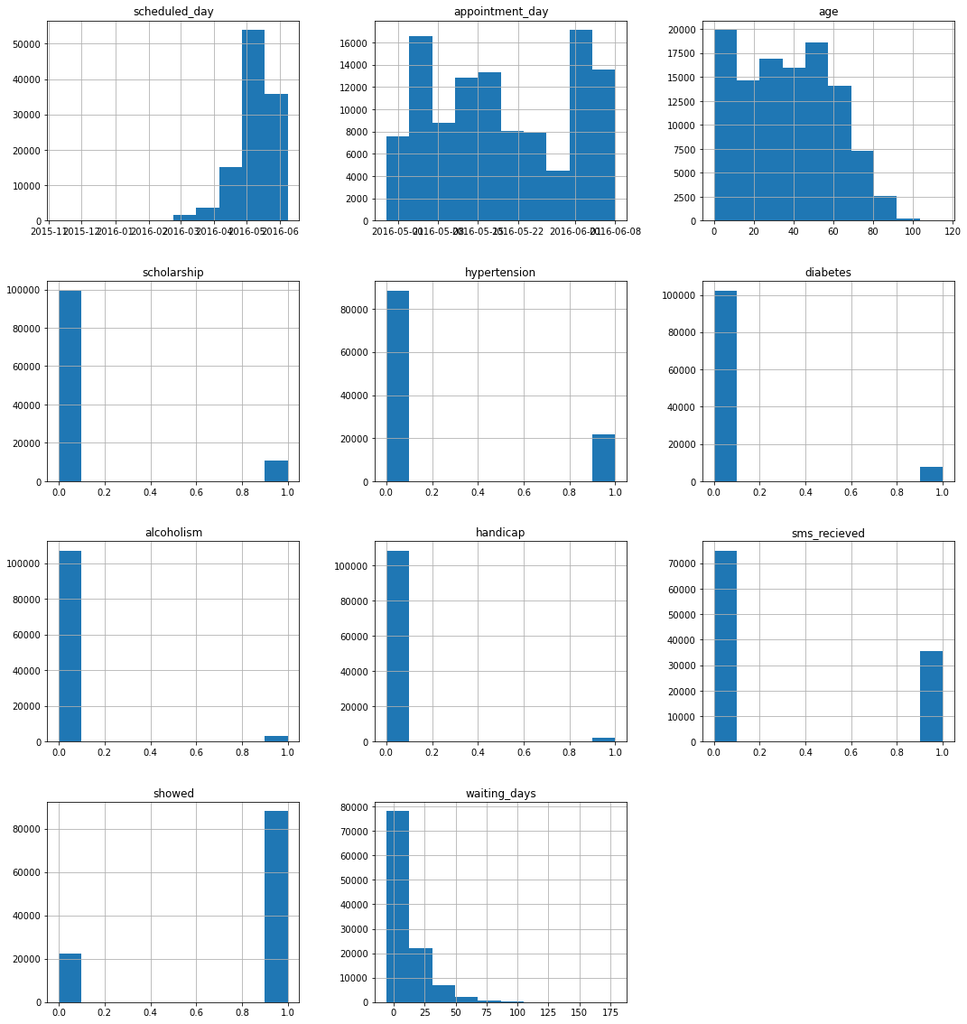

```python
df.hist(figsize=(18,20));
```

The histograms shows us the following:

Hypertension have the highest count as a condition\ Diabetes comes in the second place\ Alcoholism comes in the third place

# Q1: Can age affect showing at the appointments

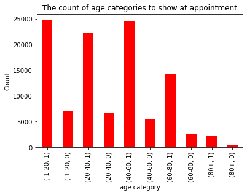

```python
df.groupby('age_category')['showed'].value_counts().plot(kind='bar',color='red')
plt.title('The count of age categories to show at appointment')
plt.ylabel('Count')
plt.xlabel('age category');
```

The least category to no show at the appointment is +80

## Q2: Can condition affect why indivduals might not show up for their appointments?

#### creating plots for the conditions and show means

```python
def condition_plot(column):
    df.groupby(column)[['showed']].mean().plot(kind='bar')
    plt.ylabel('mean value')
    plt.xlabel('{}'.format(column))
    plt.title('{}'.format(column+' show ratio'))
```

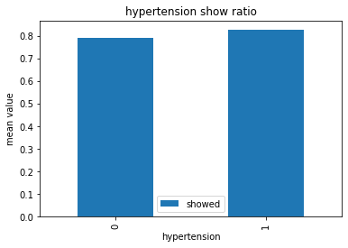

```python
condition_plot('hypertension')
```

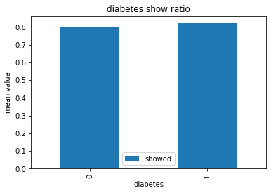

```python
condition_plot('diabetes')
```

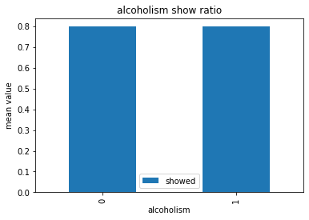

```python
condition_plot('alcoholism')
```

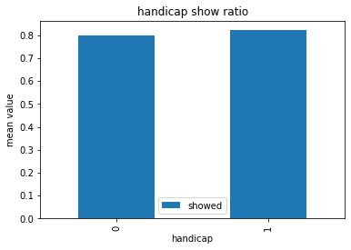

```python
condition_plot('handicap')
```

Patients condition can't be used to predict if the patient will show up, more data are needed for further analysis.

## Q3: does gender affect why indivduals might not show up for their appointments

```python
def percent(df):
   return df.value_counts()/df.count()*100
```

```python
gender_percent=percent(df['gender'])
```

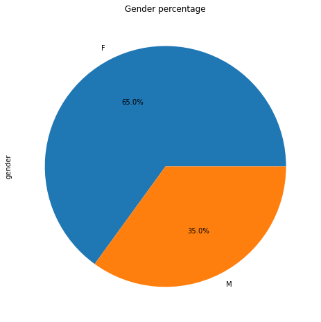

```python
gender_percent.plot(kind='pie',labels=('F','M'),figsize=(8,8),autopct='%1.1f%%')
plt.title('Gender percentage');
```

65% of the patients are females and 35% are males

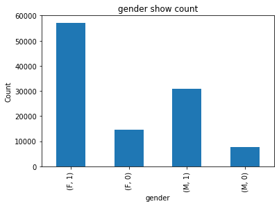

```python
df.groupby('gender')['showed'].value_counts().plot(kind='bar')
plt.ylabel('Count')
plt.xlabel('gender')
plt.title('gender show count');
```

## Q4: Does The waiting days affect on showing to the appointment

```python
df.drop(df.query('waiting_days<0').index, inplace=True)
```

```python
wait_plot=df.groupby('waiting_days')[['showed']].count()
```

```python
wait_plot
```

| waiting_days | showed |
| --- | --- |
| 0 | 38485 |
| 1 | 5204 |
| 2 | 6712 |
| 3 | 2730 |
| 4 | 5279 |
| ... | ... |
| 155 | 10 |
| 162 | 11 |
| 169 | 8 |
| 176 | 16 |
| 179 | 10 |

129 rows × 1 columns

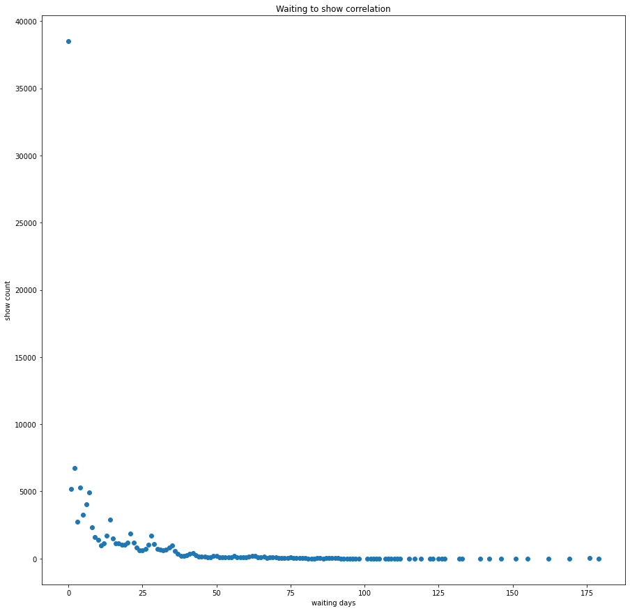

```python
plt.subplots(figsize=(15,15))
plt.scatter(x=wait_plot.index,y=wait_plot['showed'])
plt.title('Waiting to show correlation')
plt.ylabel('show count')
plt.xlabel('waiting days');
```

There is a negative correlation between the waiting days and showing to medical appointments

## Q5: What are the top and least neighborhoods to no show up for their appointments

```python
# Create show and no show dataframe where they are filtered by "Yes" and "No"
show = df[df['showed']==1]
noshow = df[df['showed']==0]
```

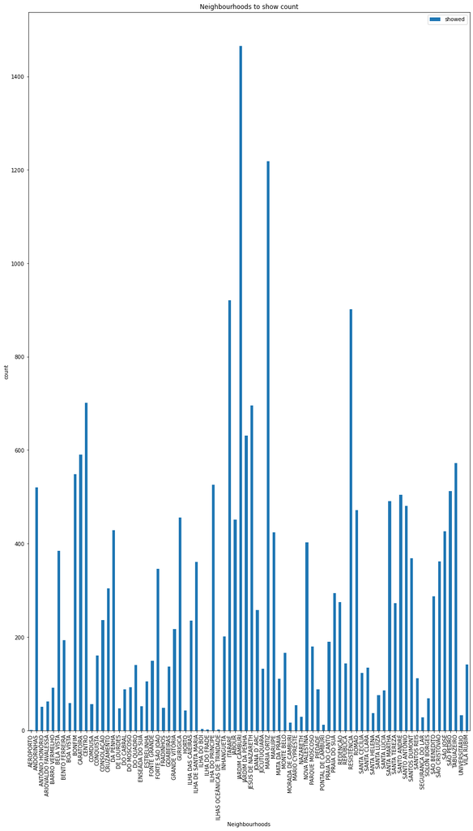

```python
noshow.groupby('neighbourhood')[['showed']].count().plot(kind='bar',figsize=(15,25))
plt.title('Neighbourhoods to show count')
plt.xlabel('Neighbourhoods')
plt.ylabel('count');
```

results are not clear

```python
# assigning the above result to a dataframe to sort it and cleaerify the results
neighbourhood_noshow=noshow.groupby('neighbourhood')[['showed']].count()
neighbourhood_noshow.sort_values(by='showed',ascending=False, inplace = True)
neighbourhood_noshow
```

| neighbourhood | showed |
| --- | --- |
| JARDIM CAMBURI | 1465 |
| MARIA ORTIZ | 1219 |
| ITARARÉ | 921 |
| RESISTÊNCIA | 902 |
| CENTRO | 701 |
| ... | ... |
| PONTAL DE CAMBURI | 12 |
| ILHA DO BOI | 3 |
| ILHAS OCEÂNICAS DE TRINDADE | 2 |
| ILHA DO FRADE | 2 |
| AEROPORTO | 1 |

80 rows × 1 columns

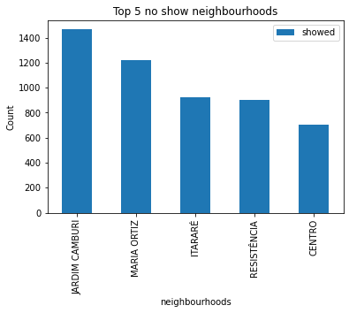

```python
# Top 5 no show Neighbourhoods
neighbourhood_noshow.head(5).plot(kind= 'bar')
plt.ylabel('Count')
plt.title('Top 5 no show neighbourhoods')
plt.xlabel('neighbourhoods');
```

The top 5 no show neighbourhoods are **JARDIM CAMBURI, MARIA ORTEZ, ITARARE, RESISTENCIA** and **CENTRO**

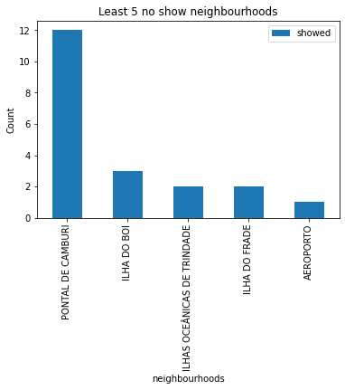

```python
# least 5 no show neighbourhoods
neighbourhood_noshow.tail(5).plot(kind= 'bar')
plt.ylabel('Count')
plt.title('Least 5 no show neighbourhoods')
plt.xlabel('neighbourhoods');
```

The least 5 no show neighbourhoods are **PONTAL DE CAMBURI, ILHA DO BOI, ILHAS OCEANICAS DE TRINDADE, ILHA DO FRADE** and **AEROPORTO**

## Q6: Does not recieving sms affect not showing to the appointments

```python
recieved_sms= percent(df['sms_recieved'])
show_recieved_sms= percent(show['sms_recieved'])
noshow_recieved_sms= percent(noshow['sms_recieved'])
```

```python
print('total patients recieved sms percentage:\n', recieved_sms )
print('patients recieved sms and showed percentage:\n', show_recieved_sms)
print('patients recieved sms and did not show percentage:\n', noshow_recieved_sms)
```

```
total patients recieved sms percentage:
 0    67.880387
1    32.119613
Name: sms_recieved, dtype: float64
patients recieved sms and showed percentage:
 0    70.857136
1    29.142864
Name: sms_recieved, dtype: float64
patients recieved sms and did not show percentage:
 0    56.112782
1    43.887218
Name: sms_recieved, dtype: float64
```

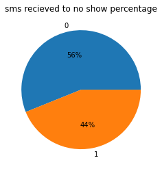

```python
plt.pie(noshow.groupby('sms_recieved')['showed'].count(),autopct='%1.0f%%',labels=(0,1))
plt.title('sms recieved to no show percentage');
```

Given that 68% of the patient's appintments didn't receive SMS, we can't rule that SMS is the reason why they didn't show up

## Conclusion

According to the data and stats we explored :

Neighbourhood Hospitals varies between not showing to the appointments as some neighborhood have higher not showing rates than others,further analysis is required to answer specific neighbourhood questions.

Gender:  
65% of the entries are Female and 35% are Male which might lead to a skewed results if we explored their condition

we can notice that those who received SMS about their appointments represents 32% of total appointments, patients who showed up to their appointments only 29% of them received SMS while 71% didn't receive it but still showed up, Those who didn't show up received a higher rate of SMS at 43.8%.

waiting days:  
have negative effect on showing to the appointment but not a large effect \ **Final conclusion** in order to predict whether the patients are going to show up or not, we will need more data like (Income , Marital status, kids, Job type)